# Chao and Albert Applied Project

Albert Mandizha, Chao Yang

2022-11-30

# Multiple Linear Regression

# 1. Clean Environment & Load Libraries

```r
library(caret)
library(caTools)
library(dplyr)
```

# 2. Source, Collect and Load Data

## 2.1 Source and Collect Data

Our data is collected online based on existed numbers.

## 2.2 Load Data

Importing the dataset

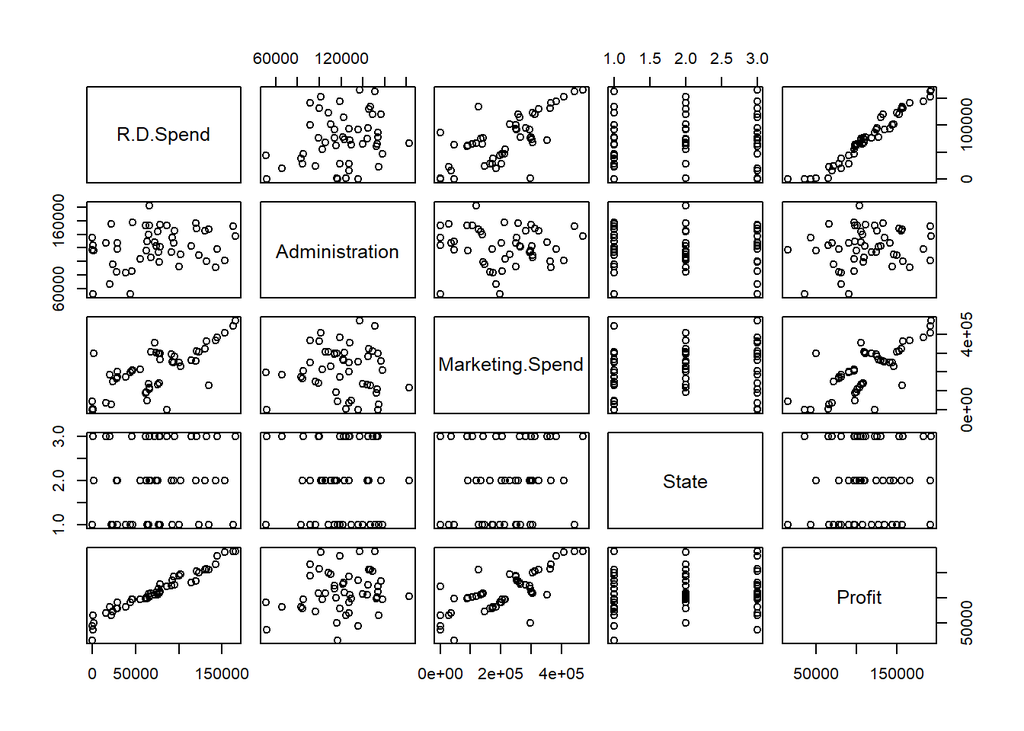

```r
dataset = read.csv("50_Startups.csv")
plot(dataset)
```

# 3. Data preprocessing and Data cleaning

## 3.1 Explore missing value patterns

## 3.2 Check if there are NA values

```r
NANumbers <- sum(is.na(dataset))
paste("**** The number of NA values in this data set =", NANumbers)
```

```
## [1] "**** The number of NA values in this data set = 0"
```

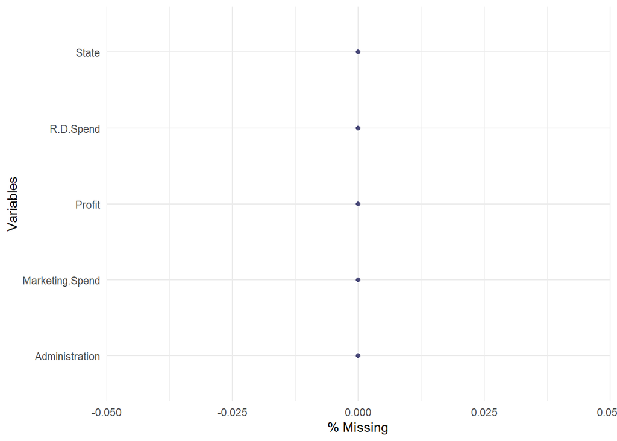

```r
# Plotting percentage of missing values per feature
library(naniar)
gg_miss_var(dataset, show_pct = TRUE)
```

# 3.3 Data parsing (Set dummy variables)

We don’t have dummy variables to set in our dataset

## 3.3.1 Encoding categorical data

```r
dataset$State = factor(dataset$State,
                       levels = c('New York', 'California', 'Florida'),
                       labels = c(1, 2, 3))
dataset$State=as.integer(dataset$State)
# Display new data frame
head(dataset)
```

```
##   R.D.Spend Administration Marketing.Spend State   Profit
## 1  165349.2      136897.80        471784.1     1 192261.8
## 2  162597.7      151377.59        443898.5     2 191792.1
## 3  153441.5      101145.55        407934.5     3 191050.4
## 4  144372.4      118671.85        383199.6     1 182902.0
## 5  142107.3       91391.77        366168.4     3 166187.9
## 6  131876.9       99814.71        362861.4     1 156991.1
```

## 3.4 Data histograms

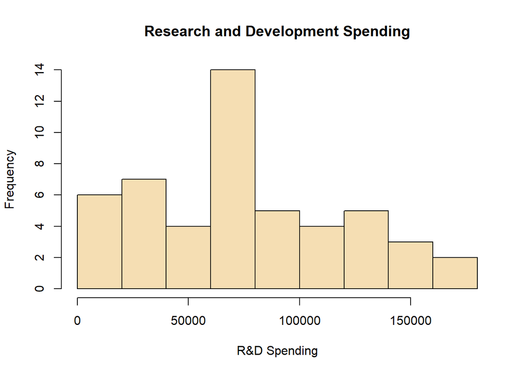

```r
par(mfrow=c(1,1))
hist(dataset$R.D.Spend, col = "wheat",main = "Research and Development Spending",xlab = "R&D Spending")
```

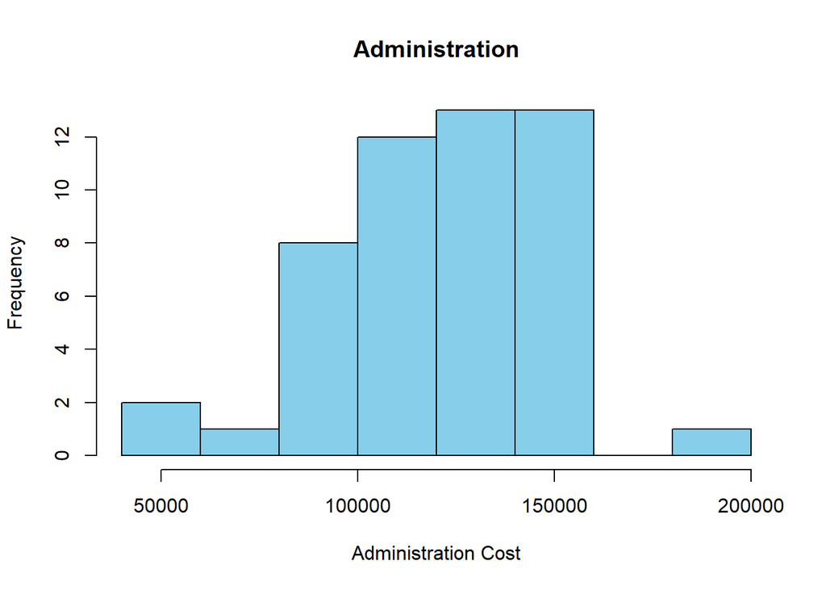

```r
hist(dataset$Administration, col = "skyblue",main = "Administration",xlab = "Administration Cost")
```

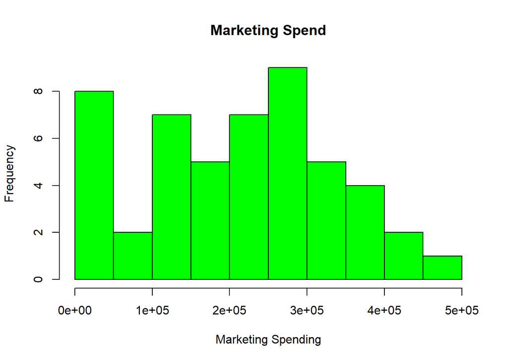

```r
hist(dataset$Marketing.Spend, col = "green", main = "Marketing Spend",xlab = "Marketing Spending")
```

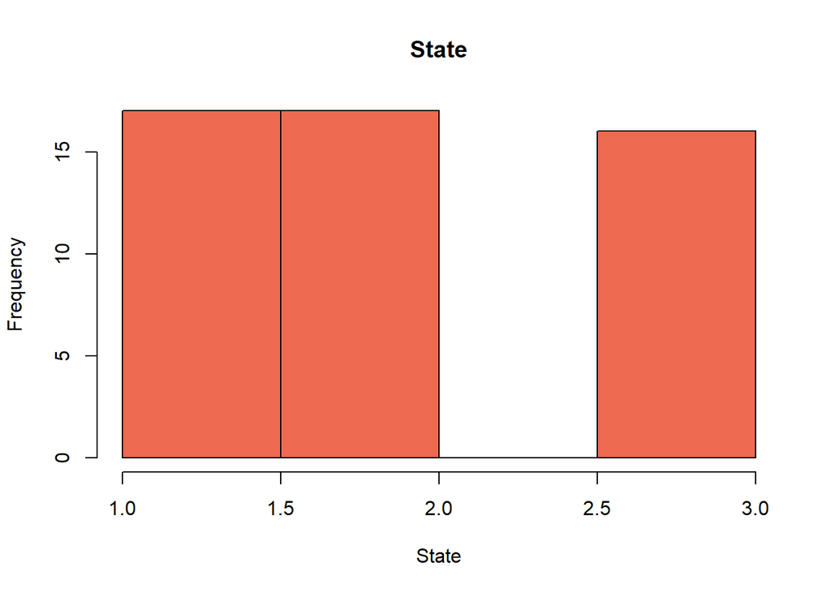

```r
hist(dataset$State, col = "coral2",main = "State",xlab = "State")
```

## 3.4.1 Kernel Density Plot

Density curves allow us to quickly see whether or not a graph is left skewed, right skewed, or has no skew. We see there are no features that their density have no skew.

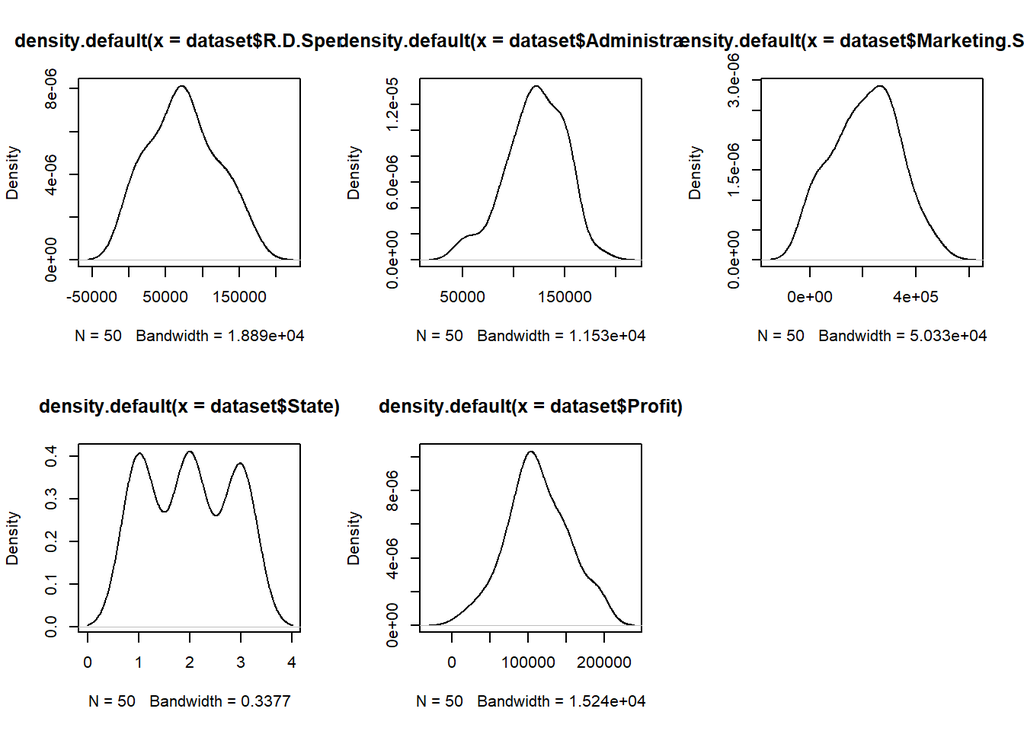

```r
library(ggplot2)
par(mfrow=c(2,3))
plot(density(dataset$R.D.Spend))
plot(density(dataset$Administration))
plot(density(dataset$Marketing.Spend))
plot(density(dataset$State))
plot(density(dataset$Profit))
```

## 3.5 Checking & Treating Outliers

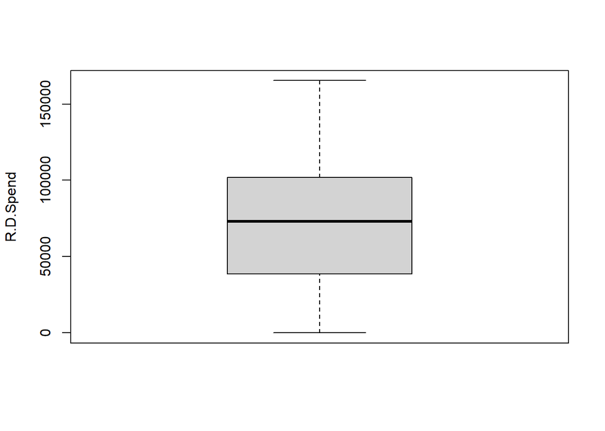

```r
boxplot(dataset$R.D.Spend,
        ylab = "R.D.Spend")
```

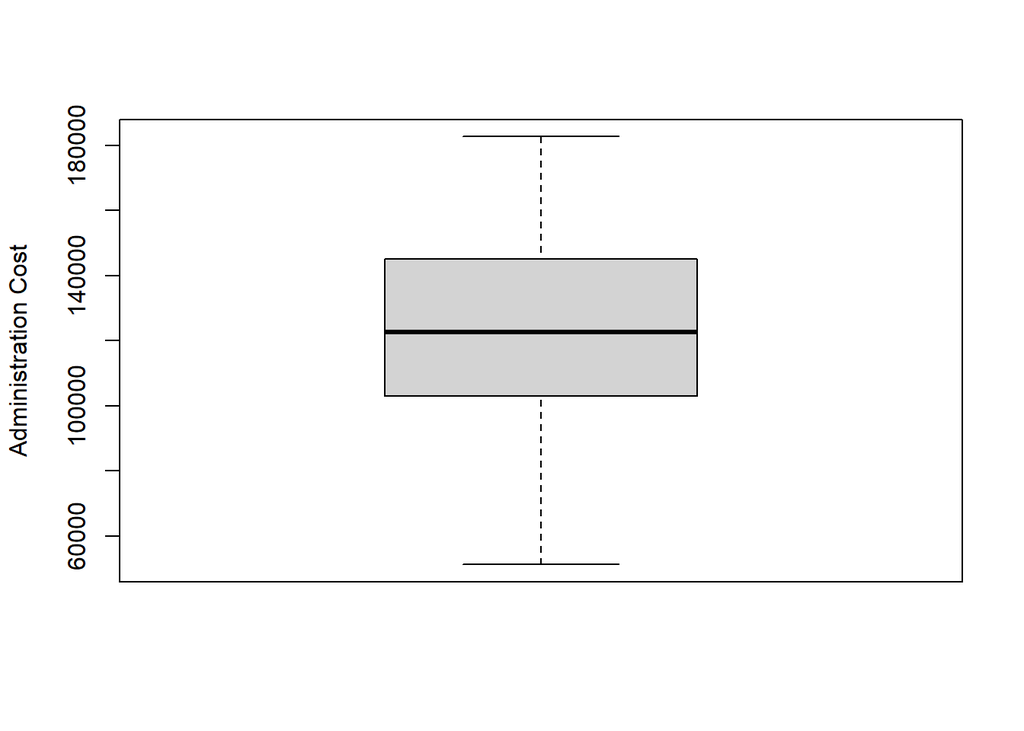

```r
boxplot(dataset$Administration,
        ylab = "Administration Cost")
```

```r
boxplot.stats(dataset$Administration)$out
```

```
## numeric(0)
```

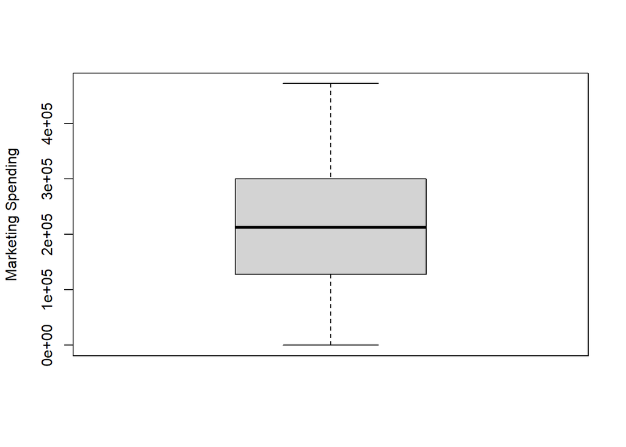

```r
boxplot(dataset$Marketing.Spend,
        ylab = "Marketing Spending")
```

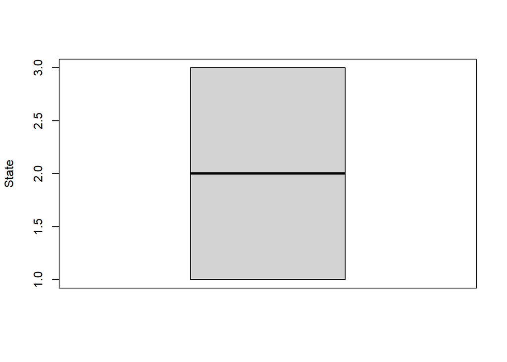

```r
boxplot(dataset$State,
        ylab = "State")
```

It can be noted that from the boxplots there are no outliers from the dataset.

## 3.6 Data Correlation Analysis

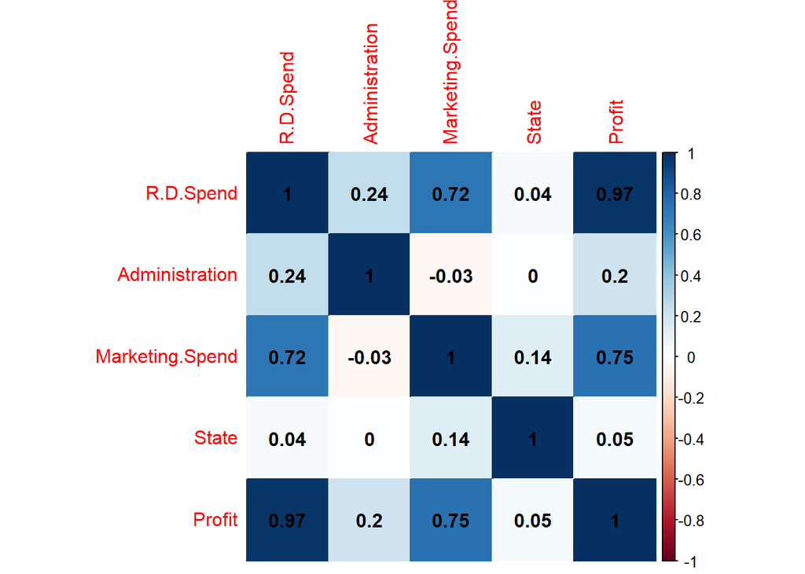

```r
library(corrplot)
corrplot(cor(dataset), addCoef.col = 'black', method="color")
```

#4.0 Data Analysis Stage

## 4.1 Splitting the dataset into the Training set and Test set

```r
library(caret)
set.seed(123)
training.samples=dataset$Profit%>%
  createDataPartition(p=.8, list =FALSE)
training_set=dataset[training.samples,]
test_set=dataset[-training.samples,]
```

## 4.2 Model Fitting Multiple Linear Regression to the Training set

```r
library(Metrics)
regressor = lm(formula = Profit ~ .,
               data = training_set)
summary(regressor)
```

```
##
## Call:
## lm(formula = Profit ~ ., data = training_set)
##
## Residuals:
##      Min       1Q   Median       3Q      Max
## -30896.3  -4638.4    758.2   6770.3  16049.2
##
## Coefficients:
##                   Estimate Std. Error t value Pr(>|t|)
## (Intercept)      4.797e+04  8.090e+03   5.930 7.82e-07 ***
## R.D.Spend        8.292e-01  4.887e-02  16.967  < 2e-16 ***
## Administration  -4.863e-02  5.667e-02  -0.858    0.396
## Marketing.Spend  3.115e-02  1.860e-02   1.675    0.102
## State            9.455e+02  1.853e+03   0.510    0.613
## ---
## Signif. codes:  0 '***' 0.001 '**' 0.01 '*' 0.05 '.' 0.1 ' ' 1
##
## Residual standard error: 9500 on 37 degrees of freedom
## Multiple R-squared:  0.9504, Adjusted R-squared:  0.945
## F-statistic: 177.1 on 4 and 37 DF,  p-value: < 2.2e-16
```

```r
predy = predict(regressor, newdata = test_set)
mse <- mse(training_set$Profit,predy)
cat("MSE" , mse, "\n")
```

```
## MSE 3592993407
```

```r
coef(regressor)
```

```
##     (Intercept)       R.D.Spend  Administration Marketing.Spend           State
##    4.796872e+04    8.291682e-01   -4.863310e-02    3.115408e-02    9.454625e+02
```

```r
confint(regressor)
```

```
##                         2.5 %       97.5 %
## (Intercept)      3.157735e+04 6.436008e+04
## R.D.Spend        7.301466e-01 9.281898e-01
## Administration  -1.634631e-01 6.619686e-02
## Marketing.Spend -6.527932e-03 6.883608e-02
## State           -2.808957e+03 4.699882e+03
```

## 4.3 Hypothesis test on coefficients of alpha value is setting as 0.05

```r
#H0: Bi = 0, i =0,1,2,3,4
#Ha: Bi != 0
#Reject Ha fs F0 > F(0.05,4,37)
F_critical = qf(p=.05, df1=4, df=37, lower.tail=FALSE)
F_statistic = 177.1
F_critical < F_statistic
```

```
## [1] TRUE
```

```r
#Hence we reject H0, which means there are relationships between independent variables and dependent variables.
```

## 4.4 Preparing X and Y vectors for lasso regression

```r
x_train <- model.matrix(training_set$Profit~., data = training_set)[, -1]
y_train <- training_set$Profit
```

## 4.5 Displaying how the coefficients vary with lambda

```r
library(glmnet)
```

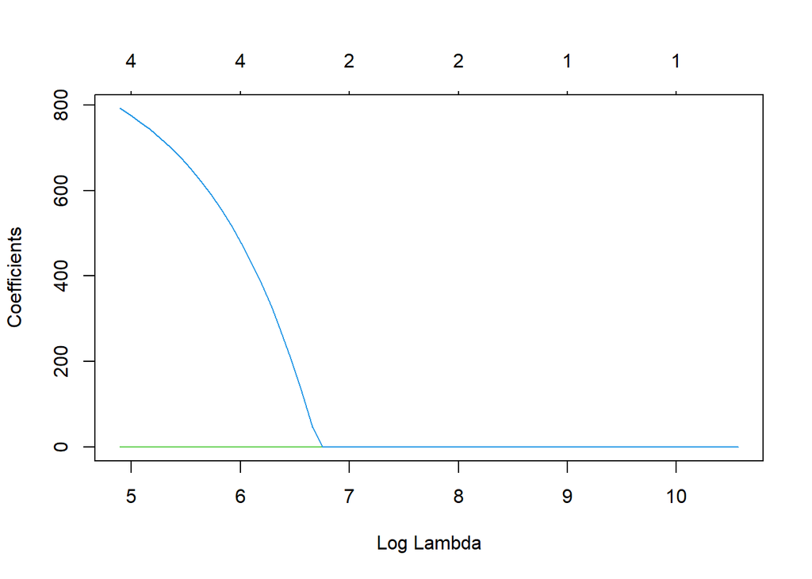

```r
lasso_model <- glmnet(x_train, y_train, alpha = 1)
plot(lasso_model, "lambda")
```

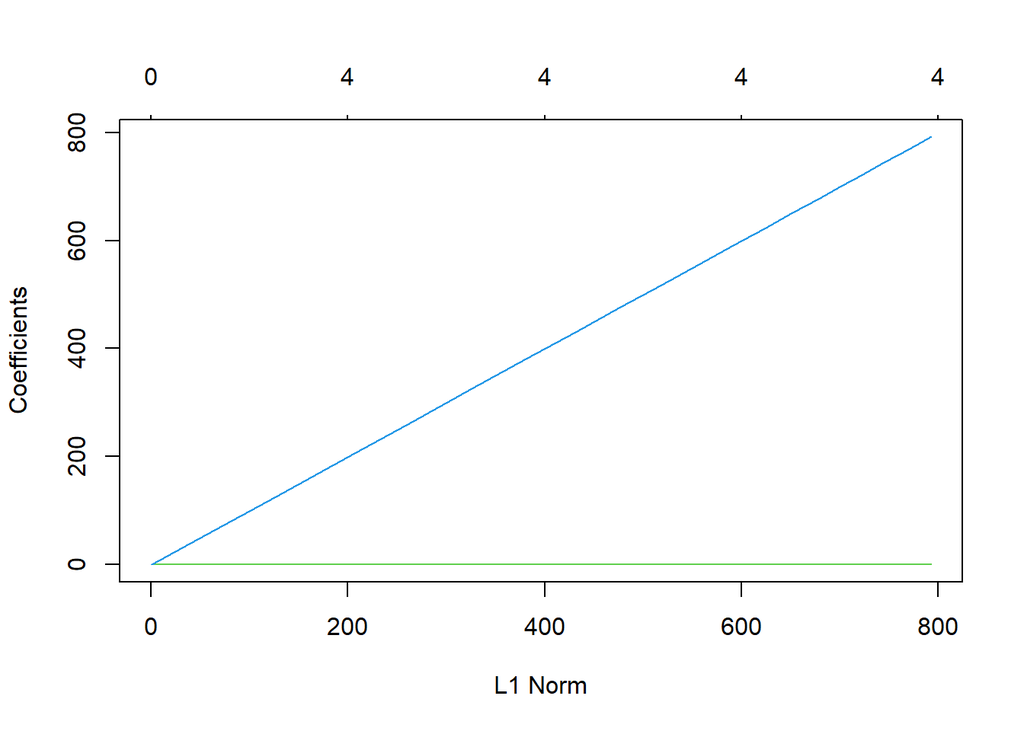

```r
plot(lasso_model, "norm")
```

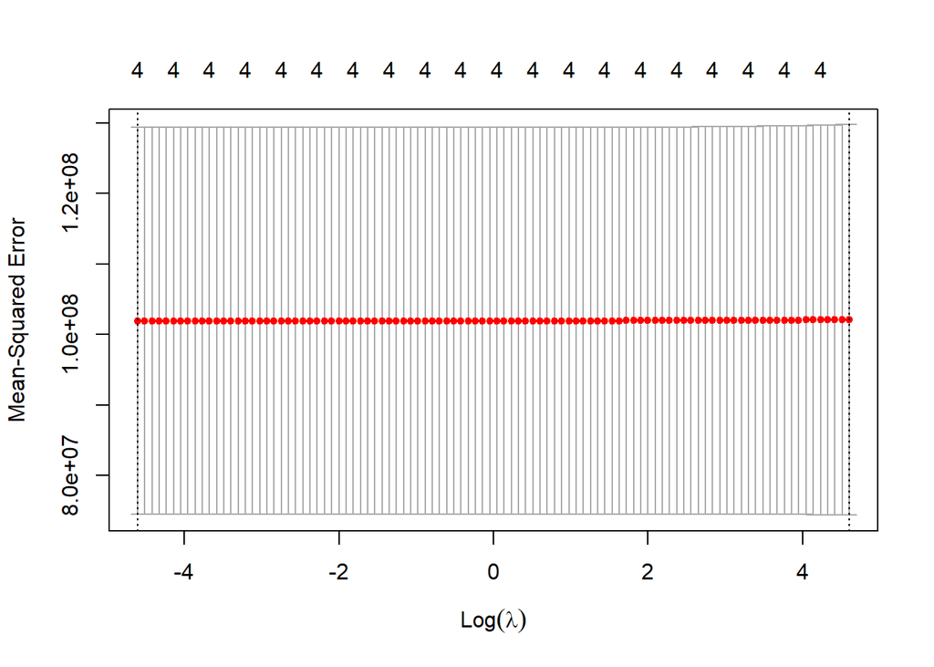

```r
set.seed(4)
grid <- 10^seq(2, -2, length = 100)
lasso_cv_model <- cv.glmnet(x_train, y_train, alpha = 1, lambda = grid)
plot(lasso_cv_model)
```

```r
best_lambda <- lasso_cv_model$lambda.min
cat("Best Lambda: ", best_lambda, "\n")
```

```
## Best Lambda:  0.01
```

```r
coef(lasso_cv_model)
```

```
## 5 x 1 sparse Matrix of class "dgCMatrix"
##                            s1
## (Intercept)      4.783428e+04
## R.D.Spend        8.259521e-01
## Administration  -4.375055e-02
## Marketing.Spend  3.122857e-02
## State            8.307380e+02
```

## 4.6 Performance on test data

```r
library(Metrics)
x_test <- model.matrix(test_set$Profit~. , data = test_set)[, -1]
lasso_pred <- predict(lasso_cv_model, s = best_lambda, newx = x_test)
test_mse <- mse(test_set$Profit, lasso_pred)
cat("Test MSE" , test_mse, "\n")
```

```
## Test MSE 90907605
```

# 5.0 Model Accuracy

## 5.1. Make predictions

```r
predictions <- regressor %>% predict(test_set)
```

## 5.2 Model performance

### 5.2.1 (a) Compute the prediction error, RMSE

```r
RMSE(predictions, test_set$Profit)
```

```
## [1] 9534.568
```

### 5.2.2 (b) Compute R-square

```r
R2(predictions, test_set$Profit)
```

```
## [1] 0.9801895
```

## 5.3 Conclusion

From the output above, the R2 is 0.98, meaning that the observed and the predicted outcome values are highly correlated, which is very good.

```r
Error_rate= 9534.568/mean(test_set$Profit)
Error_rate
```

```
## [1] 0.08379864
```

The prediction error RMSE is 9534.568, representing an error rate of 9534.568/mean(test_set$Profit) = 8.3%, which is good.